# Figure for Johan

JJayes

2022-06-07

## Purpose

Figure planning for Johan about how to visualize his matched sample from the tax census and petitions to the government.

## Planning

The plan is to make a figure that shows two things:

1. The share of individuals who are petitioners matched to the tax census, as a proportion of the tax census.
2. For each petitioner who appears in the tax census each year, how many years do they appear in the tax census.

Let’s start with each of the petitioners. We create a set of 400 fake names with the `ch_generate` function from the [**charlatan** package](https://docs.ropensci.org/charlatan/).

```r
library(charlatan)
petitioners <- ch_generate(n = 400) %>%
  select(petitioner = name)

petitioners %>% head() %>% knitr::kable(col.names = "Example names")
```

| Example names |
| --- |
| Orange O’Connell |
| Alvaro Kuhn |
| Emerald Willms |
| Leland Fay |
| Ms. Pennie Nikolaus |
| Baylie Bins |

Now we generate for each year, a dummy variable for whether these individuals are in the tax census dataset.

```r
years <- 1751:1800 %>% as_tibble() %>% rename(year = value)

is_in <- function(petitioner) {
  runif(50, 0, 1) %>%
    as_tibble() %>%
    mutate(value = ifelse(value > .9, 1, 0)) %>%
    bind_cols(years) %>%
    pivot_wider(names_from = year, values_from = value)
}

petitioners <- petitioners %>%
  mutate(is_in_dataset = map(petitioner, is_in)) %>%
  unnest(is_in_dataset)

petitioners %>%
  select(1:6) %>%
  head(5) %>%
  knitr::kable()
```

| petitioner | 1751 | 1752 | 1753 | 1754 | 1755 |
| --- | --- | --- | --- | --- | --- |
| Orange O’Connell | 0 | 1 | 0 | 0 | 0 |
| Alvaro Kuhn | 0 | 0 | 0 | 0 | 0 |
| Emerald Willms | 0 | 0 | 0 | 0 | 0 |
| Leland Fay | 0 | 0 | 1 | 0 | 0 |
| Ms. Pennie Nikolaus | 0 | 0 | 0 | 0 | 0 |

Now we have a dataset with 50 years and a binary indicating if the individual is in the tax census.

Original idea: just do lines to show when people enter and leave the tax census. Let’s start small with just 25 people.

```r
petitioners_time <- petitioners %>%
  pivot_longer(-petitioner, names_to = "year", values_to = "is_present") %>%
  mutate(year = as.numeric(year)) %>%
  filter(is_present == 1) %>%
  group_by(petitioner) %>%
  mutate(min_year = min(year),
         max_year = max(year),
         n_years = n()) %>%
  ungroup() %>%
  mutate(duration = max_year - min_year)
```

This chart is showing dots for each time a petitioner appears in the tax census, and a line showing the duration they are in the census. The colour of the line shows their number of observations over this period.

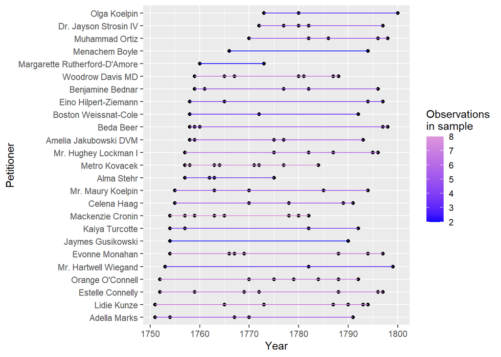

```r
petitioners_25 <- petitioners %>% select(petitioner) %>% sample_n(25)

petitioners_time %>%
  # choose just 25 petitioners
  filter(petitioner %in% petitioners_25$petitioner) %>%
  mutate(petitioner = fct_reorder(petitioner, min_year)) %>%
  ggplot(aes(x = year, y = petitioner)) +
  geom_point() +
  # line to show duration
  geom_segment(aes(
    x = min_year,
    y = petitioner,
    xend = max_year,
    yend = petitioner,
    colour = n_years
  )) +
  scale_color_gradient2(
    low = "blue", high = "red", mid = "pink",
    midpoint = 10
  ) +
  labs(
    x = "Year",
    y = "Petitioner",
    colour = "Observations\nin sample"
  )
```

We now look from the other side - how many petitioners are in the tax census, and how many times do they appear?

We want to show this as a stacked column plot.

First we need to simulate what share the petitioners make up of the tax census each year, let’s make it between 15 percent and 25 percent.

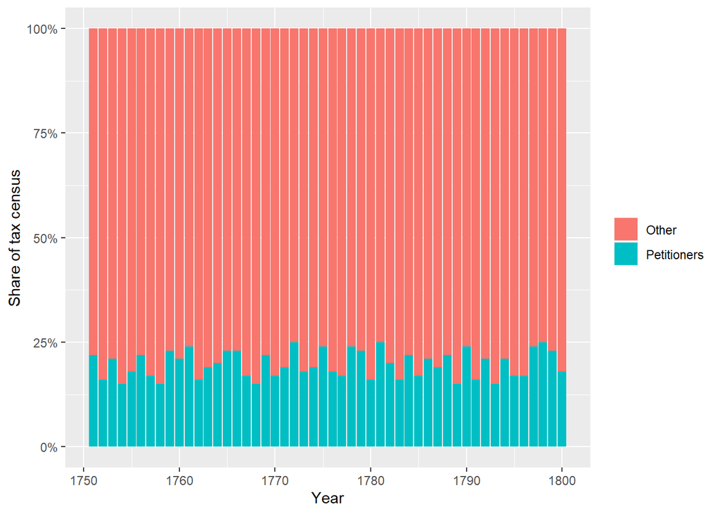

```r
share_petitioners <- runif(50, 15, 25) %>%
  as_tibble() %>%
  mutate(share_petitioners = round(value)) %>%
  select(share_petitioners)

share_petitioners <- years %>%
  bind_cols(share_petitioners) %>%
  mutate(share_other = 100 - share_petitioners)

share_petitioners %>%
  pivot_longer(-year) %>%
  mutate(name = str_to_title(str_remove(name, "share_"))) %>%
  ggplot(aes(x = year, y = value, fill = name)) +
  geom_col() +
  scale_y_continuous(labels = scales::percent_format(scale = 1)) +
  labs(x = "Year",
       y = "Share of tax census",
       fill = NULL)
```

Great, now let us choose that many petitioners from the set of petitioners each year

What’s a good way to do this??

For each year, we need to see which petitioners appear, then sample from these

```r
who_is_in <- function(year, how_many){
  petitioners_time %>%
    filter(year == year) %>%
    distinct(petitioner, n_years) %>%
    slice_sample(n = how_many)

}

share_petitioners <- share_petitioners %>%
  mutate(names = pmap(list(year, share_petitioners), who_is_in))

share_petitioners <- share_petitioners %>%
  unnest(names)

not_petitioners <- share_petitioners %>%
  select(year, n = share_other) %>%
  mutate(n_years = NA) %>%
  distinct()

colours <- scale_fill_brewer(palette = "Paired")

library(RColorBrewer)
my.cols <- brewer.pal(12, "Paired")
my.cols
```

```
##  [1] "#A6CEE3" "#1F78B4" "#B2DF8A" "#33A02C" "#FB9A99" "#E31A1C" "#FDBF6F"
##  [8] "#FF7F00" "#CAB2D6" "#6A3D9A" "#FFFF99" "#B15928"
```

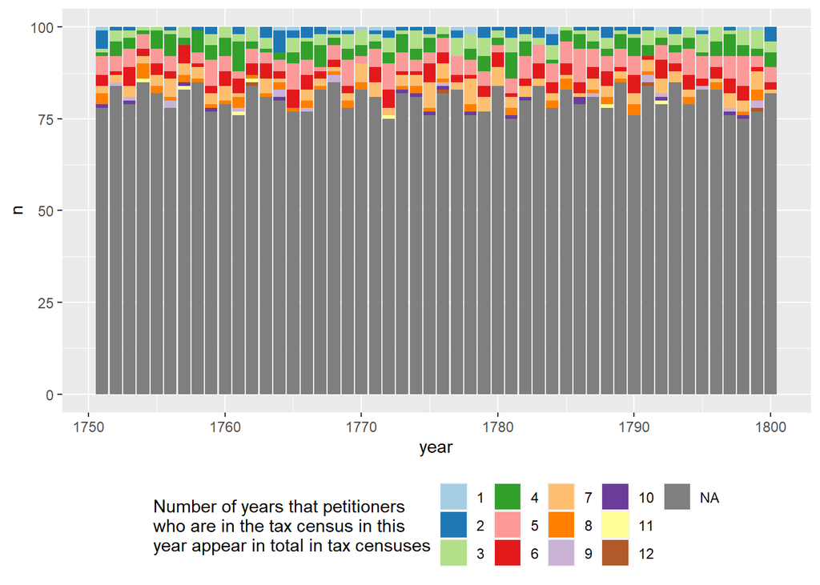

```r
share_petitioners %>%
  count(year, n_years) %>%
  bind_rows(not_petitioners) %>%
  ggplot(aes(year, n, fill = factor(n_years))) +
  scale_fill_manual(values = my.cols) +
  geom_col() +
  labs(fill = "Number of years that petitioners\nwho are in the tax census in this\nyear appear in total in tax censuses") +
  theme(legend.position = "bottom")
```

This is kinda chaotic - maybe a better colour scale will work?

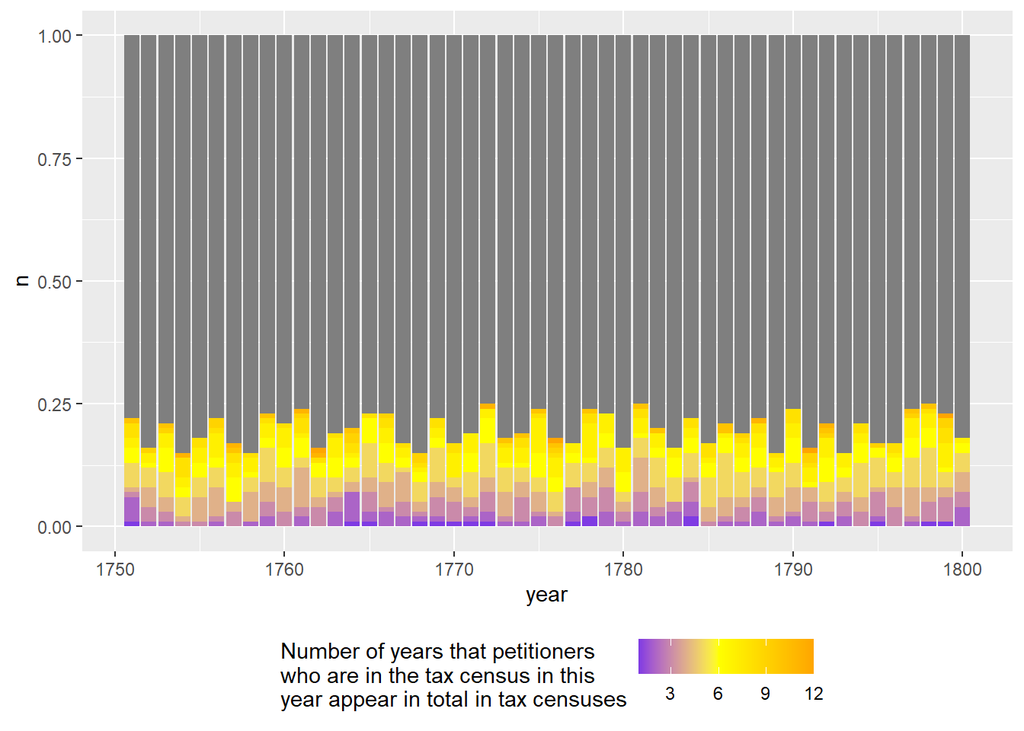

```r
share_petitioners %>%
  count(year, n_years) %>%
  bind_rows(not_petitioners) %>%
  ggplot(aes(year, n, fill = n_years)) +
  scale_fill_gradient2(low = "blue", high = "orange", mid = "yellow", midpoint = 6) +
  geom_col(position = "fill") +
  labs(fill = "Number of years that petitioners\nwho are in the tax census in this\nyear appear in total in tax censuses") +
  theme(legend.position = "bottom")
```

Maybe this is a bit better?